# **REGRESSION ASSUMPTIONS**

##### *1 Assumption : The Y-values (or the errors, “e”) are independent!*

##### *2 Assumption : The Y-values can be expressed as a linear function of the X variables*

##### *3 Assumption : Variation of observations around the regression line (the residual SE is constant (homoscedasticity)*

##### *4 Assumption : for given values of X,Y values (or the error) are Normally distributed*

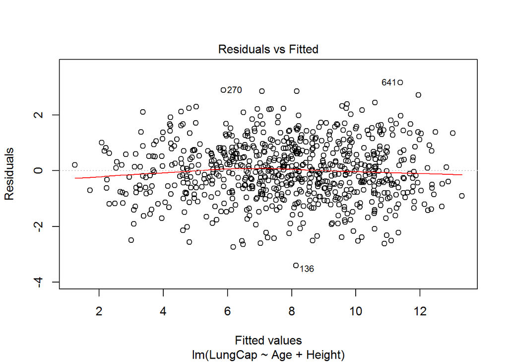

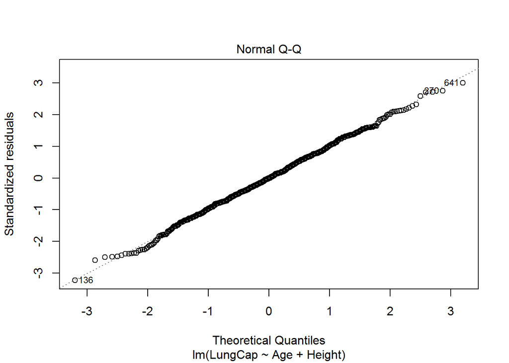

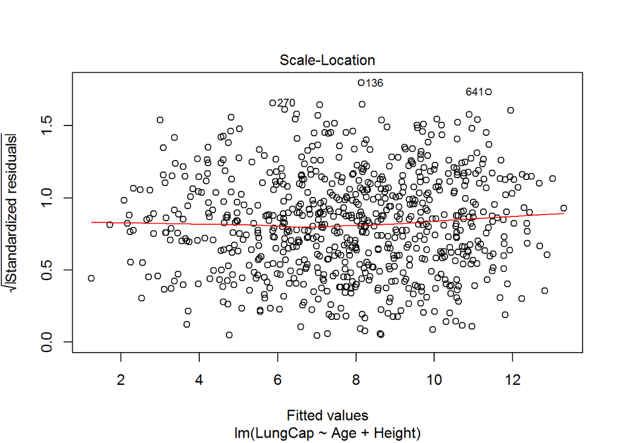

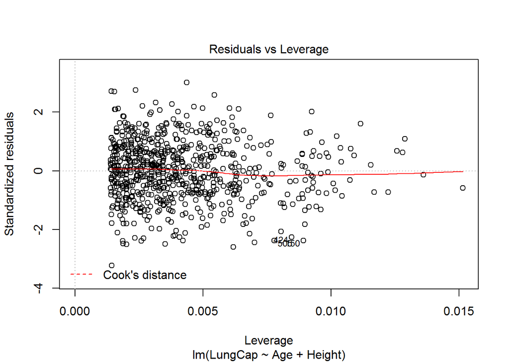

```r
plot(model1)
```

#### **LOGISTIC REGRESSION -** *is used to describe data and to explain the relationship between one dependent binary variable and one or more nominal, ordinal, interval or ratio-level independent variables.*

```r
# Read Data

data <- read.csv("LungCapData.txt",header = T,sep = "\t")
str(data)
```

```
## 'data.frame':    725 obs. of  6 variables:
##  $ LungCap  : num  6.47 10.12 9.55 11.12 4.8 ...
##  $ Age      : int  6 18 16 14 5 11 8 11 15 11 ...
##  $ Height   : num  62.1 74.7 69.7 71 56.9 58.7 63.3 70.4 70.5 59.2 ...
##  $ Smoke    : Factor w/ 2 levels "no","yes": 1 2 1 1 1 1 1 1 1 1 ...
##  $ Gender   : Factor w/ 2 levels "female","male": 2 1 1 2 2 1 2 2 2 2 ...
##  $ Caesarean: Factor w/ 2 levels "no","yes": 1 1 2 1 1 1 2 1 1 1 ...
```

```r
data <- data[c(1:4)]
```

```r
# Normalize Data

data$LungCap <- scale(data$LungCap)
data$Age <- scale(data$Age)
data$Height <- scale(data$Height)
```

```r
# Convert data to binary

levels(data$Smoke)=0:1
head(data)
```

```
##      LungCap        Age     Height Smoke
## 1 -0.5214663 -1.5798483 -0.3799252     0
## 2  0.8496790  1.4165938  1.3695539     1
## 3  0.6336766  0.9171868  0.6753161     0
## 4  1.2253352  0.4177798  0.8558180     0
## 5 -1.1506905 -1.8295518 -1.1019324     0
## 6 -0.6153804 -0.3313307 -0.8520068     0
```

```r
# Check the class imbalance

table(data$Smoke)
```

```
##
##   0   1
## 648  77
```

```r
# Data Partition

set.seed(1234)
ind <- sample(2,nrow(data),replace = T,prob = c(0.8,0.2))
train <- data[ind == 1,]
test <- data[ind == 2,]
```

```r
# Handling Class Imbalance

library(ROSE)
both <- ovun.sample(Smoke ~., data = train,method = 'both',p=0.5,seed=222,N=573)$data
table(both$Smoke)
```

```
##
##   0   1
## 287 286
```

```r
over <- ovun.sample(Smoke ~.,data = train,method = 'over',N=1296)$data
table(over$Smoke)
```

```
##
##   0   1
## 511 785
```

```r
under <- ovun.sample(Smoke ~., data = train,method = 'under',N=154)$data
table(under$Smoke)
```

```
##
##  0  1
## 92 62
```

```r
# Build a Model

mymodel <- glm(Smoke ~ LungCap + Age + Height,data = both, family = 'binomial')
```

```r
# Predict Model on Training Dataset

p <- predict(mymodel,both,type = 'response')
pred <- ifelse(p>0.5,1,0)
tab <- table(Predicted=pred,Actual=both$Smoke)
1-sum(diag(tab))/sum(tab)
```

```
## [1] 0.2879581
```

```r
# Predict model on test data

p1 <- predict(mymodel,test,type = 'response')
pred1 <- ifelse(p1 >0.5,1,0)
tab1 <- table(Predicted= pred1, Actual=test$Smoke)
1-sum(diag(tab1))/sum(tab1)
```

```
## [1] 0.2960526
```